# ONS LAD 2019 data cleaning

### GDP table

```r
str(gdp)
```

```
## tibble [382 × 24] (S3: tbl_df/tbl/data.frame)
##  $ NUTS1 Region: chr [1:382] "North East" "North East" "North East" "North East" ...
##  $ LA code     : chr [1:382] "E06000001" "E06000002" "E06000003" "E06000004" ...
##  $ LA name     : chr [1:382] "Hartlepool" "Middlesbrough" "Redcar and Cleveland" "Stockton-on-Tees" ...
##  $ 1998        : num [1:382] 1022 1693 1799 2994 1634 ...
##  $ 1999        : num [1:382] 1073 1799 2229 3105 1668 ...
##  $ 2000        : num [1:382] 1081 1828 2131 3170 1796 ...
##  $ 2001        : num [1:382] 1041 1837 2034 3194 1924 ...
##  $ 2002        : num [1:382] 1102 1925 2102 3400 2067 ...
##  $ 2003        : num [1:382] 1160 2007 2256 3681 2184 ...
##  $ 2004        : num [1:382] 1203 2189 2280 3889 2345 ...
##  $ 2005        : num [1:382] 1237 2303 2176 4046 2335 ...
##  $ 2006        : num [1:382] 1299 2466 2200 4358 2387 ...
##  $ 2007        : num [1:382] 1349 2564 2256 4518 2336 ...
##  $ 2008        : num [1:382] 1428 2646 2339 4681 2407 ...
##  $ 2009        : num [1:382] 1403 2666 2316 4845 2297 ...
##  $ 2010        : num [1:382] 1456 2669 2620 4788 2450 ...
##  $ 2011        : num [1:382] 1508 2733 2667 4817 2522 ...
##  $ 2012        : num [1:382] 1496 2842 2792 4732 2547 ...
##  $ 2013        : num [1:382] 1535 2728 2808 4847 2771 ...
##  $ 2014        : num [1:382] 1557 2762 2544 5448 2937 ...
##  $ 2015        : num [1:382] 1636 2894 2061 6121 3090 ...
##  $ 2016        : num [1:382] 1731 3112 2005 6126 2916 ...
##  $ 2017        : num [1:382] 1728 3215 2061 6040 3223 ...
##  $ 20183       : num [1:382] 1732 3388 2159 5885 3076 ...
```

#### No NAs yay

```r
sum(is.na(gdp$`2018`)) ## good news
```

```
## [1] 0
```

#### Rename, pivot, mutate

```r
gdp = gdp %>% rename(Region = `NUTS1 Region`,
                     areaCode = `LA code`,
                     areaName = `LA name`) %>%
  pivot_longer(-c(Region, areaCode, areaName),
               names_to = 'year',
               values_to = 'GDP(millionGBP)') %>%
  mutate(year = as.numeric(year))
```

Format year as it kep the superscript from the excel sheet

```r
gdp$year = ifelse(gdp$year == 20183, 2018, gdp$year)
```

#### Update codes

```r
gdp = updateCodes(gdp)

combs_dup = gdp %>%
  group_by(areaCode, areaName, year) %>% summarise(duplicat = n()>1)

print(
  gdp[gdp$areaCode %in%
              combs_dup$areaCode[combs_dup$duplicat==T],c(2,3,4)] %>%
    arrange(areaCode, areaName,year), n = 100)
```

```
## # A tibble: 0 x 3
## # … with 3 variables: areaCode <chr>, areaName <chr>, year <dbl>
```

This function combines entries by taking the **sum** when they are duplicated

```r
for (row in which(combs_dup$duplicat==T)){
  entry = combs_dup[row,]

  gdp[(gdp$areaCode == entry$areaCode &
               gdp$areaName == entry$areaName &
               gdp$year == entry$year),
            !colnames(gdp) %in% c('areaCode','areaName', 'year')] =
    t(apply(gdp[(gdp$areaCode == entry$areaCode &
                         gdp$areaName == entry$areaName &
                         gdp$year == entry$year),
                      !colnames(gdp) %in% c('areaCode','areaName', 'year')],2,sum))

}

print(
  gdp[gdp$areaCode %in%
        combs_dup$areaCode[combs_dup$duplicat==T],c(2,3,4, 5)] %>%
    arrange(areaCode, areaName,year), n = 100)
```

```
## # A tibble: 0 x 4
## # … with 4 variables: areaCode <chr>, areaName <chr>, year <dbl>,
## #   `GDP(millionGBP)` <dbl>
```

Check what min and max years are

```r
min(gdp$year)
```

```
## [1] 1998
```

```r
max(gdp$year)
```

```
## [1] 2018
```

```r
gdp_time = gdp
gdp = gdp_time %>% filter(year == max(year))
```

### Unemployment

This one is easy to handle as it is almost tidy, we just got to choose the column we are interested in which is the one with the unemployment rate in 2019. Because it is 2019 arleady, we don’t even need to update the LAD codes

```r
str(unemployment)
```

```
## tibble [372 × 209] (S3: tbl_df/tbl/data.frame)
##  $ UALAD               : chr [1:372] NA NA "County Durham" "Darlington" ...
##  $ ...2                : chr [1:372] NA NA "E06000047" "E06000005" ...
##  $ ...3                : logi [1:372] NA NA NA NA NA NA ...
##  $ 1996/97             : chr [1:372] "Rate" NA ":" "9.3000000000000007" ...
##  $ ...5                : chr [1:372] "+/- (%)2" NA ":" "2" ...
##  $ ...6                : logi [1:372] NA NA NA NA NA NA ...
##  $ 1997/98             : chr [1:372] "Rate" NA ":" "8" ...
##  $ ...8                : chr [1:372] "+/- (%)2" NA ":" "1.8" ...
##  $ ...9                : logi [1:372] NA NA NA NA NA NA ...
##  $ 1998/99             : chr [1:372] "Rate" NA ":" "7" ...
##  $ ...11               : chr [1:372] "+/- (%)2" NA ":" "1.8" ...
##  $ ...12               : logi [1:372] NA NA NA NA NA NA ...
##  $ 1999/2000           : chr [1:372] "Rate" NA ":" "8.0999999999999996" ...
##  $ ...14               : chr [1:372] "+/- (%)2" NA ":" "2" ...
```

[output cut: 86 more lines]

```r
unemployment = unemployment[3:nrow(unemployment), -seq(3, ncol(unemployment), 3)]
```

The date format for this table is confusing so I am not gonna take care of the tidying yet

```r
unemployment_time = unemployment[, c(1,2,seq(3, ncol(unemployment), 2))]
colnames(unemployment_time)[1:2] = c('areaName', 'areaCode')
unemployment_time = unemployment_time %>% pivot_longer(-c(areaName, areaCode),
                                                       names_to = 'year',
                                                       values_to = 'UnempRate')

unemployment = unemployment[, c(1, 2, ncol(unemployment)-1)]

colnames(unemployment) = c('areaName', 'areaCode', 'UnempRate')
unemployment$year = 2019
```

## Merge Data

For each dataset the data that has been taken it’s that for the latest available year, we’ll log what that is for each dataframe

#### Time-series data frame

```r
ONS_time = Reduce(function(x,y) merge(x = x, y = y,
                                      by = c('areaCode', 'areaName', 'year'),
                                      all = TRUE),
                  list(popclean_time, gdp_time, lifeexpect_time, suicides_time,
                       unemployment, wellbeing_time, work_time))

write.csv(ONS_time, 'CleanData/ONStime.csv')
## unemployment_time year format is impossible to understand and it is too much time to preprocess it
```

#### Most current data

```r
years_for_dfs = data.frame(df = character(),
                           year = integer(),
                           yearColumn = character())


for (obj in ls()){
  if ('data.frame' %in% class(eval(parse(text = obj))) &
      (obj != 'years_for_dfs' &
      obj != 'tst' &
      !grepl('_time', obj) &
      obj != 'unemployment') &
      obj != 'ONS_time'
      ){
    years_for_dfs[nrow(years_for_dfs)+1, 'df'] = obj
    curr_df = eval(parse(text = obj))
    years_for_dfs[nrow(years_for_dfs), 'year'] =
      ifelse('year' %in% colnames(curr_df),
             curr_df$year, NA)
    years_for_dfs[nrow(years_for_dfs), 'yearColumn'] =
      ifelse('year' %in% colnames(curr_df),
             'year', NA)

    #remove year column
    if ('year' %in% colnames(curr_df)){
      curr_df = curr_df[,-which(colnames(curr_df) == 'year')]
    }

    eval(parse(text = paste(obj, ' = curr_df')))
  }
}
kable(years_for_dfs)
```

| df | year | yearColumn |
| --- | --- | --- |
| age | 2018 | year |
| agetotal | 2018 | year |
| combs_dup | 1998 | year |
| entry | 2018 | year |
| gdp | 2018 | year |
| lifeexpect | 2017 | year |
| popclean | 2018 | year |
| population | 2005 | year |
| suicides | 2018 | year |
| wellbeing | 2019 | year |
| work | 2019 | year |
| work_ts | 2018 | year |

```r
remove(obj)
```

### MERGE!

As it can be seen in the function call below we are performing outer joins(`all = TRUE`)

```r
ONS = Reduce(function(x,y) merge(x = x, y = y,
                                 by = c('areaCode', 'areaName'),
                                 all = TRUE),
             list(popclean, gdp, lifeexpect, suicides,
                  unemployment, wellbeing, work))
```

Finally we can visualise the missingness in the final dataset, though you may need a magnifier!

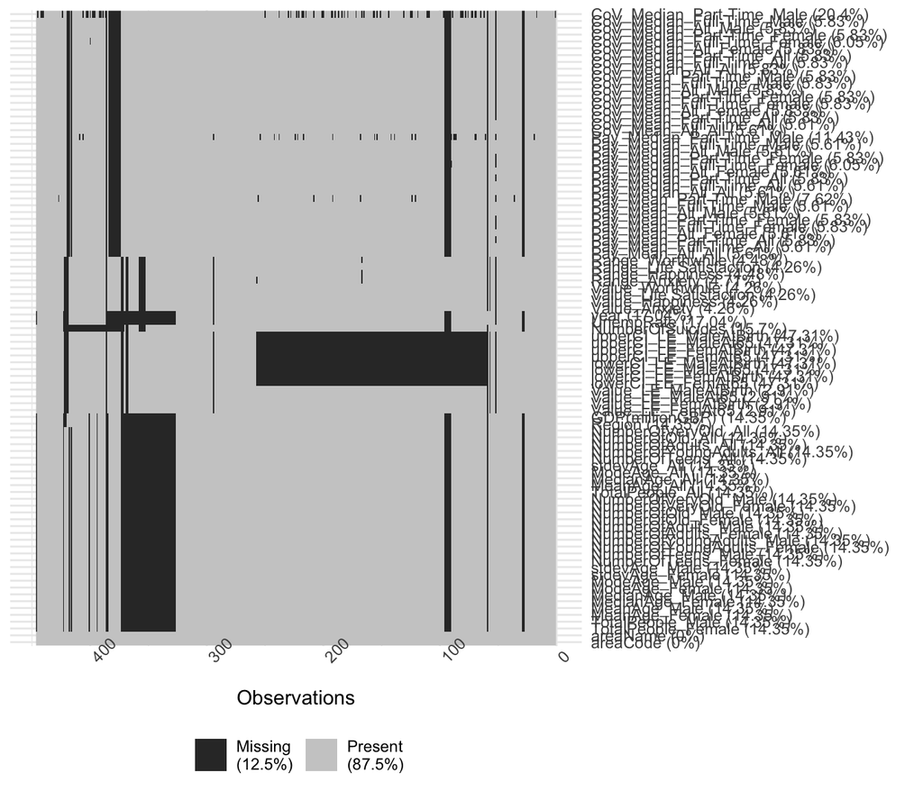

```r
vis_miss(ONS)+coord_flip()
```

### Save all data

```r
write.csv(ONS, 'CleanData/ONS.csv')
```

after this run:

```r
rmarkdown::render('01_tidyingOriginalData.R',
                output_format = c('html_document','pdf_document'))
```